# Analysis_Manoj

```r
#import the libraries we need
library(jsonlite)
library(glue)
library(readr)
library(lmtest)
library(forecast)
library(DIMORA)
library(ggplot2)
library(quantmod)
library(TTR) # Technical Trading Rules
```

```r
btc <- read_csv("M://Crypto_Analysis/BTC-USD.csv", show_col_types = FALSE)
eth <- read_csv("M://Crypto_Analysis/ETH-USD.csv", show_col_types = FALSE)
btc1 <- read_csv("M://Crypto_Analysis/BTC-USD-1.csv", show_col_types = FALSE)
```

```r
btc
```

| Date | Weekday | Open | High | Low | Close | Adjusted | Volume |
| --- | --- | --- | --- | --- | --- | --- | --- |
| 01/12/2017 | 5 | 10198.600 | 11046.700 | 9694.650 | 10975.600 | 10975.600 | 6783119872 |
| 02/12/2017 | 6 | 10978.300 | 11320.200 | 10905.100 | 11074.600 | 11074.600 | 5138500096 |
| 03/12/2017 | 7 | 11082.700 | 11858.700 | 10862.000 | 11323.200 | 11323.200 | 6608309760 |
| 04/12/2017 | 1 | 11315.400 | 11657.200 | 11081.800 | 11657.200 | 11657.200 | 6132409856 |
| 05/12/2017 | 2 | 11685.700 | 12032.000 | 11604.600 | 11916.700 | 11916.700 | 6895260160 |
| 06/12/2017 | 3 | 11923.400 | 14369.100 | 11923.400 | 14291.500 | 14291.500 | 12656300032 |
| 07/12/2017 | 4 | 14266.100 | 17899.699 | 14057.300 | 17899.699 | 17899.699 | 17950699520 |
| 08/12/2017 | 5 | 17802.900 | 18353.400 | 14336.900 | 16569.400 | 16569.400 | 21135998976 |
| 09/12/2017 | 6 | 16523.301 | 16783.000 | 13674.900 | 15178.200 | 15178.200 | 13911300096 |
| 10/12/2017 | 7 | 15168.400 | 15850.600 | 13226.600 | 15455.400 | 15455.400 | 13433299968 |

[output cut: 990 more lines]

```r
eth
```

| Date | Day | Open | High | Low | Close | Adj Close | Volume |
| --- | --- | --- | --- | --- | --- | --- | --- |
| 01/12/2017 | Fri | 445.20902 | 472.60901 | 428.31201 | 466.54001 | 466.54001 | 1247879936 |
| 02/12/2017 | Sat | 466.85101 | 476.23901 | 456.65301 | 463.44900 | 463.44900 | 943649984 |
| 03/12/2017 | Sun | 463.70499 | 482.81399 | 451.85199 | 465.85300 | 465.85300 | 990556992 |
| 04/12/2017 | Mon | 466.05399 | 474.77701 | 453.31201 | 470.20401 | 470.20401 | 1005550016 |
| 05/12/2017 | Tue | 470.29401 | 473.55801 | 457.66000 | 463.28101 | 463.28101 | 1216720000 |
| 06/12/2017 | Wed | 462.60400 | 462.70801 | 420.20999 | 428.58801 | 428.58801 | 1998259968 |
| 07/12/2017 | Thu | 426.36899 | 441.39700 | 414.41101 | 434.40799 | 434.40799 | 2129570048 |
| 08/12/2017 | Fri | 434.98901 | 466.06201 | 422.36700 | 456.03101 | 456.03101 | 2336379904 |
| 09/12/2017 | Sat | 457.34399 | 504.14700 | 456.25299 | 473.50201 | 473.50201 | 2003849984 |
| 10/12/2017 | Sun | 472.78900 | 472.78900 | 429.51401 | 441.72101 | 441.72101 | 1404179968 |

[output cut: 990 more lines]

```r
NA
```

```r
btc
```

| Date | Weekday | Open | High | Low | Close | Adjusted | Volume |
| --- | --- | --- | --- | --- | --- | --- | --- |
| 01/12/2017 | 5 | 10198.600 | 11046.700 | 9694.650 | 10975.600 | 10975.600 | 6783119872 |
| 02/12/2017 | 6 | 10978.300 | 11320.200 | 10905.100 | 11074.600 | 11074.600 | 5138500096 |
| 03/12/2017 | 7 | 11082.700 | 11858.700 | 10862.000 | 11323.200 | 11323.200 | 6608309760 |
| 04/12/2017 | 1 | 11315.400 | 11657.200 | 11081.800 | 11657.200 | 11657.200 | 6132409856 |
| 05/12/2017 | 2 | 11685.700 | 12032.000 | 11604.600 | 11916.700 | 11916.700 | 6895260160 |
| 06/12/2017 | 3 | 11923.400 | 14369.100 | 11923.400 | 14291.500 | 14291.500 | 12656300032 |
| 07/12/2017 | 4 | 14266.100 | 17899.699 | 14057.300 | 17899.699 | 17899.699 | 17950699520 |
| 08/12/2017 | 5 | 17802.900 | 18353.400 | 14336.900 | 16569.400 | 16569.400 | 21135998976 |
| 09/12/2017 | 6 | 16523.301 | 16783.000 | 13674.900 | 15178.200 | 15178.200 | 13911300096 |
| 10/12/2017 | 7 | 15168.400 | 15850.600 | 13226.600 | 15455.400 | 15455.400 | 13433299968 |

[output cut: 990 more lines]

```r
eth
```

| Date | Day | Open | High | Low | Close | Adj Close | Volume |
| --- | --- | --- | --- | --- | --- | --- | --- |
| 01/12/2017 | Fri | 445.20902 | 472.60901 | 428.31201 | 466.54001 | 466.54001 | 1247879936 |
| 02/12/2017 | Sat | 466.85101 | 476.23901 | 456.65301 | 463.44900 | 463.44900 | 943649984 |
| 03/12/2017 | Sun | 463.70499 | 482.81399 | 451.85199 | 465.85300 | 465.85300 | 990556992 |
| 04/12/2017 | Mon | 466.05399 | 474.77701 | 453.31201 | 470.20401 | 470.20401 | 1005550016 |
| 05/12/2017 | Tue | 470.29401 | 473.55801 | 457.66000 | 463.28101 | 463.28101 | 1216720000 |
| 06/12/2017 | Wed | 462.60400 | 462.70801 | 420.20999 | 428.58801 | 428.58801 | 1998259968 |
| 07/12/2017 | Thu | 426.36899 | 441.39700 | 414.41101 | 434.40799 | 434.40799 | 2129570048 |
| 08/12/2017 | Fri | 434.98901 | 466.06201 | 422.36700 | 456.03101 | 456.03101 | 2336379904 |
| 09/12/2017 | Sat | 457.34399 | 504.14700 | 456.25299 | 473.50201 | 473.50201 | 2003849984 |
| 10/12/2017 | Sun | 472.78900 | 472.78900 | 429.51401 | 441.72101 | 441.72101 | 1404179968 |

[output cut: 990 more lines]

Since, Five days corresponds to one week of trading days, 10 days corresponds to two weeks of trading days, and 20 days corresponds to approximately one month of trading days we have removed Saturday and Sunday where most trades does not happen.

Relative Strength Index Indicator <- It is a momentum indicator that measures the magnitude of recent price changes to analyze overbought or oversold conditions.

Readings below 30 generally indicate that the stock is oversold, while readings above 70 indicate that it is overbought.Generally, 14 days are use as default for computation purposes.

```r
for_date <- function(x){
  return(as.Date(as.POSIXct(strptime(x,"%d/%m/%Y"))))
}
```

```r
mod_date= lapply(btc[2:1796,1],for_date)
```

```r
btc.xts <- xts(btc[1:1795,2:8],order.by=mod_date$Date)
```

```r
btc.xts <- subset(btc.xts, btc.xts$Weekday!=6 & btc.xts$Weekday!=7)

#man.xts <- subset(btc.xts$Adjusted, man.xts$Weekday!=6 & btc.xts$Weekday!=7)

#n.xts <- man.xts[,2]
```

```r
btc <- subset(btc, btc$Weekday!=6 & btc$Weekday!=7)
eth <- subset(eth, eth$Day!="Sat" & eth$Day!="Sun")
```

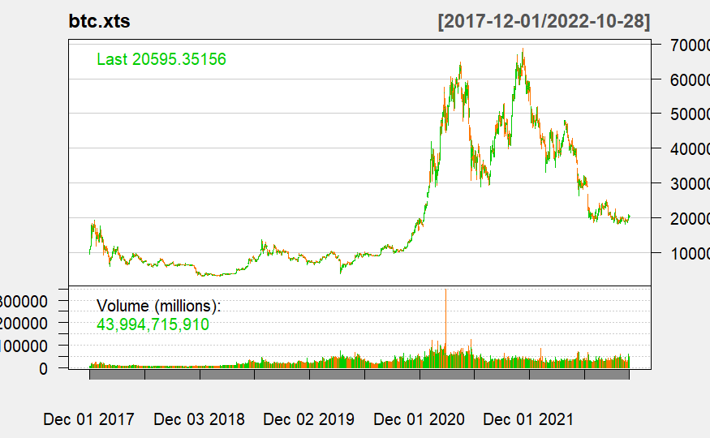

```r
rsi <- RSI(Cl(btc.xts),n=14)
barChart(btc.xts,theme=chartTheme("white"))
```

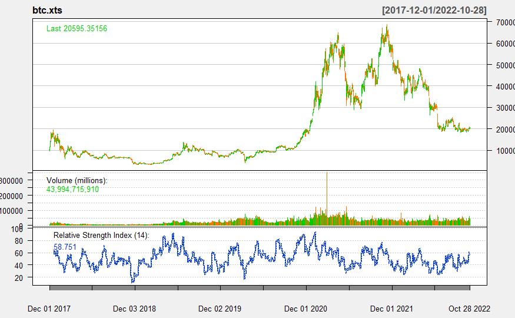

```r
addRSI(n=14)
```

stochastic oscillator <- The stochastic oscillator is a momentum indicator that relates the location of each day’s close relative to the high/low range over the past 14 days.

nFastK <- number of past periods to use(14 is chosen) nFastD <- number smoothing periods to apply to fastK. nSlowD <- the number smoothing periods to apply to fastD.

```r
stochOSC <-stoch(btc.xts[,c("High","Low","Close")],nFastK = 14,
  nFastD = 3,
  nSlowD = 3,)
StoFASTK = stochOSC$fastK
StoFASTD = stochOSC$fastD
StoSLOWK = stochOSC$slowD
tail(stochOSC,10)
```

```
               fastK     fastD     slowD
2022-10-17 0.5893675 0.5043085 0.4350983
2022-10-18 0.4857839 0.4965699 0.4724292
2022-10-19 0.3924756 0.4892090 0.4966958
2022-10-20 0.3513973 0.4098856 0.4652215
2022-10-21 0.4082441 0.3840390 0.4277112
2022-10-24 0.4911254 0.4169223 0.4036156
2022-10-25 0.8503593 0.5832429 0.4614014
2022-10-26 0.9359536 0.7591461 0.5864371
2022-10-27 0.7508705 0.8457278 0.7293723
2022-10-28 0.8690824 0.8519689 0.8189476
```

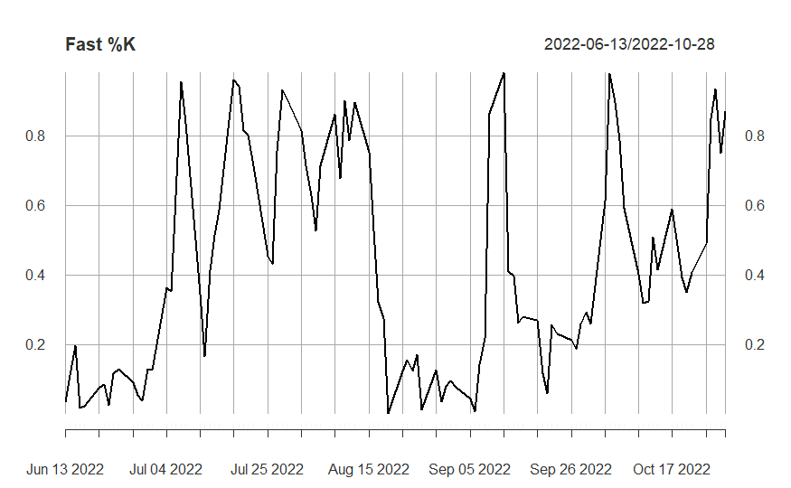

```r
plot(tail(stochOSC[,"fastK"], 100), type="l",
    main="Fast %K ", ylab="")
```

The average directional index (ADX) is used to determine when the price is trending strongly.Some people only use this indicator to initiate Buy or Sell.

If AdX values is in range of:

0-25 Absent or Weak Trend 25-50 Strong Trend 50-75 Very Strong Trend 75-100 Extremely Strong Trend

```r
adx <- ADX(btc.xts[,c("High","Low","Close")])$ADX
tail(adx,10)
```

```
                ADX
2022-10-17 14.96861
2022-10-18 14.84850
2022-10-19 14.76175
2022-10-20 14.91506
2022-10-21 15.35289
2022-10-24 15.01613
2022-10-25 14.50004
2022-10-26 14.82623
2022-10-27 15.12913
2022-10-28 15.07766
```

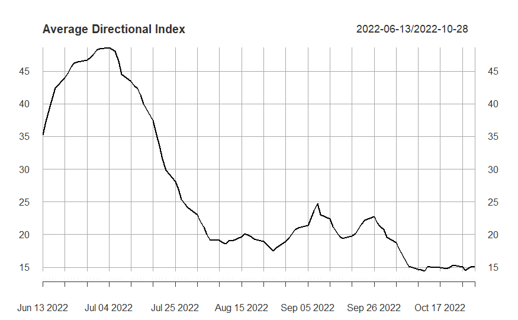

```r
plot(tail(adx, 100), type="l",
    main="Average Directional Index ", ylab="")
```

Price rate of change is calculated by subtracting the old value from the current value of the variable and dividing it by the old value. It is expressed as a percentage.

```r
roc <- ROC(btc.xts[,"Close"])
tail(roc,n=3)
```

```
                 Close
2022-10-26  0.03301719
2022-10-27 -0.02360798
2022-10-28  0.01514249
```

On-balance volume (OBV) is a technical indicator of momentum, using volume changes to make price predictions.

```r
obv <- OBV(btc.xts[,"Close"], btc.xts[,"Volume"])
tail(obv,n=3)
```

```
                    obv
2022-10-26 1.429521e+12
2022-10-27 1.379896e+12
2022-10-28 1.423891e+12
```

The Money Flow Index (MFI) is a technical oscillator that uses price and volume data for identifying overbought or oversold signals in an asset

```r
mfi <- MFI(btc.xts[,"Close"], btc.xts[,"Volume"], n =14)
tail(mfi,n=3)
```

```
                mfi
2022-10-26 57.63282
2022-10-27 55.00958
2022-10-28 62.01127
```

The Williams Accumulation / Distribution (AD) line is a measure of market momentum.

Distribution of the security is indicated when the security is making a new high and the A/D indicator is failing to make a new high. Sell.

Accumulation of the security is indicated when the security is making a new low and the A/D indicator is failing to make a new low. Buy.

```r
ad <- williamsAD(btc.xts[,c("High","Low","Close")])
tail(ad,n=3)
```

```
               [,1]
2022-10-26 39863.19
2022-10-27 39294.98
2022-10-28 39804.26
```

Moving averages are used by investors and traders to track and identify trends by smoothing normal day-to-day price fluctuations.

For example 50 day Moving average calculates average price of BTC over past 50 days which can be used for support, resistance level indicator.

```r
MA50 <-SMA(Cl(btc.xts),n=50)
MA200 <-SMA(Cl(btc.xts),n=200)
tail(MA50,n=3)
```

```
                SMA
2022-10-26 19920.23
2022-10-27 19861.69
2022-10-28 19856.05
```

```r
tail(MA200,n=3)
```

```
                SMA
2022-10-26 29718.25
2022-10-27 29616.28
2022-10-28 29536.97
```

An EMA is a type of moving average (MA) that places a greater weight and significance on the most recent data points.

```r
macd <- MACD(Cl(btc.xts), nFast=14, nSlow=3,
             nSig=9, percent=FALSE)
MACD <- macd$macd
MACDSignal <- macd$signal
tail(macd,n=5)
```

```
                 macd     signal
2022-10-24   85.07285  144.58936
2022-10-25 -234.89670   68.69215
2022-10-26 -605.23785  -66.09385
2022-10-27 -547.68116 -162.41132
2022-10-28 -599.71691 -249.87243
```

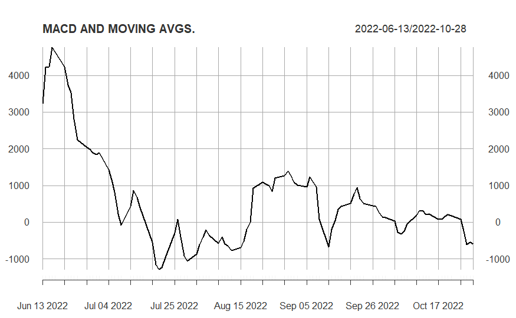

```r
plot(tail(MACD, 100), type="l",
    main="MACD AND MOVING AVGS.", ylab="")
```

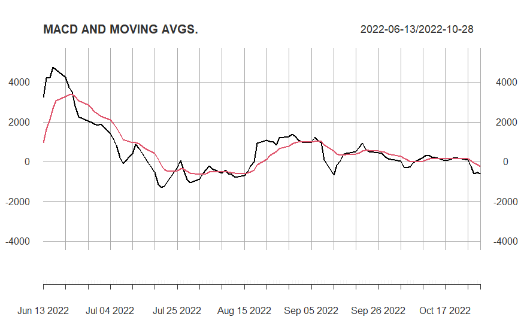

```r
lines(MACDSignal, lwd=2, col=2)
```

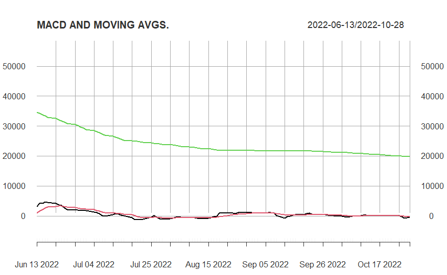

```r
lines(MA50, lwd=2, col=3)
```

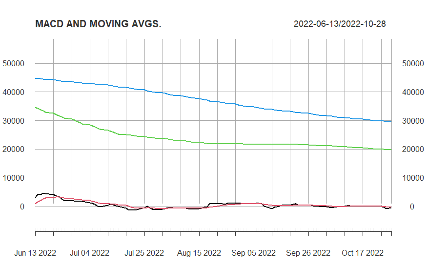

```r
lines(MA200, lwd=2, col=4)
```

Macro-Economic Variables:

Economic policy uncertainty(EPU) is measured using the US economic policy uncertainty index and economic market uncertainty is measured using the economic market uncertainty index(EMU).

```r
EPU <- read_csv("C://Users/manoj/Desktop/BEFD_Project_Images/EPU.csv",show_col_types = FALSE)
EMU <- read_csv("C://Users/manoj/Desktop/BEFD_Project_Images/EMU.csv",show_col_types = FALSE)
```

We get values of 5 working days in week

```r
EPU <- subset(EPU, EPU$Day!="Sat" & EPU$Day!="Sun")$USEPUINDXD
EMU <- subset(EMU, EMU$Day!="Sat" & EMU$Day!="Sun")$WLEMUINDXD
```

Check null and na values if wxist in EPU and EMU

```r
is.null(EPU)
```

```
[1] FALSE
```

```r
is.null(EMU)
```

```
[1] FALSE
```

```r
sum(is.na(EPU))
```

```
[1] 0
```

```r
sum(is.na(EMU))
```

```
[1] 0
```

Interest rates are measured using the yield on the US ten-year bond (Tenyrbond), three-month T-bill (ThreemTbill), and the spread (spread) between these variables.

```r
Tenyrbond <- read_csv("C://Users/manoj/Desktop/BEFD_Project_Images/Tenyrbond.csv",show_col_types = FALSE)$THREEFY10
ThreemTbill <- read_csv("C://Users/manoj/Desktop/BEFD_Project_Images/ThreemTbill.csv",show_col_types = FALSE)$DTB3
```

In this dataset the Sat and Sun are already removed therefore check of na and null values need to be done.

```r
is.null(Tenyrbond)
```

```
[1] FALSE
```

```r
is.null(ThreemTbill)
```

```
[1] FALSE
```

```r
sum(is.na(Tenyrbond))
```

```
[1] 0
```

```r
sum(is.na(ThreemTbill))
```

```
[1] 0
```

We can see there are coloumns which contains just “.” instead of null or na so we need to replace

```r
Tenyrbond['.' == Tenyrbond] = round(mean(as.numeric(Tenyrbond[-which('.' == Tenyrbond)])),4)
ThreemTbill['.' == ThreemTbill] = round(mean(as.numeric(ThreemTbill[-which('.' == ThreemTbill)])),4)
```

Equity and oil market uncertainty is measured using the VIX and the OVX respectively. The VIX is the CBOE volatility index that represents the US stock market expectations of volatility for the next 30 days. OVX is an estimate of the expected volatility over the next thirty days of the US crude oil prices.

```r
OVX <- read_csv("C://Users/manoj/Desktop/BEFD_Project_Images/OVX.csv",show_col_types = FALSE)$OVX
VIX <- read_csv("C://Users/manoj/Desktop/BEFD_Project_Images/VIX.csv",show_col_types = FALSE)$VIXCLS
```

In this dataset the Sat and Sun are already removed therefore check of na and null values need to be done.

```r
is.null(OVX)
```

```
[1] FALSE
```

```r
is.null(VIX)
```

```
[1] FALSE
```

```r
sum(is.na(OVX))
```

```
[1] 0
```

```r
sum(is.na(VIX))
```

```
[1] 0
```

We can see there are columns which contains just “.” instead of null or na so we need to replace with mean.

```r
OVX['.' == OVX] = round(mean(as.numeric(OVX[-which('.' == OVX)])),2)
VIX['.' == VIX] = round(mean(as.numeric(VIX[-which('.' == VIX)])),2)
```

Variables are included for expected five-year inflation (Fiveyrinfexp) and break-even inflation (be_inflation). The equity market volatility infectious disease tracker (EMV_IDT) is included to account for the impact of the COVID-19 pandemic.

```r
Fiveyrinfexp <- read_csv("C://Users/manoj/Desktop/BEFD_Project_Images/Fiveyrinfexp.csv",show_col_types = FALSE)
dat=Fiveyrinfexp$Date
Fiveyrinfexp <- Fiveyrinfexp$T5YIE
be_inflation <- read_csv("C://Users/manoj/Desktop/BEFD_Project_Images/be_inflation.csv",show_col_types = FALSE)$T10YIE
EMV_IDT <- read_csv("C://Users/manoj/Desktop/BEFD_Project_Images/EMV_IDT.csv",show_col_types = FALSE)
```

In the Fiveyrinfexp & be_inflation datasets the Sat and Sun are already removed therefore check of na and null values need to be done but for EMV_IDT has sat and sumday therefore the subset must be considered for that dataset.

```r
EMV_IDT <- subset(EMV_IDT, EMV_IDT$Day!="Sat" & EMV_IDT$Day!="Sun")$INFECTDISEMVTRACKD
is.null(Fiveyrinfexp)
```

```
[1] FALSE
```

```r
is.null(be_inflation)
```

```
[1] FALSE
```

```r
is.null(EMV_IDT)
```

```
[1] FALSE
```

```r
sum(is.na(Fiveyrinfexp))
```

```
[1] 0
```

```r
sum(is.na(be_inflation))
```

```
[1] 0
```

```r
sum(is.na(EMV_IDT))
```

```
[1] 1
```

```r
which(is.na(EMV_IDT))
```

```
[1] 1262
```

```r
EMV_IDT[is.na(EMV_IDT)] <- mean(EMV_IDT, na.rm = TRUE)
```

```r
Fiveyrinfexp['.' == Fiveyrinfexp] = round(mean(as.numeric(Fiveyrinfexp[-which('.' == Fiveyrinfexp)])),2)

be_inflation['.' == be_inflation] = round(mean(as.numeric(be_inflation[-which('.' == be_inflation)])),2)
```

```r
final_df = data.frame(dat,btc.xts$Open,btc.xts$High,btc.xts$Low,btc.xts$Close,btc.xts$Adjusted,btc.xts$Volume,rsi,StoFASTK,StoFASTD,StoSLOWK,adx,roc,obv,mfi,ad,MA50,MA200,MACD,MACDSignal,EPU,EMU,Tenyrbond,ThreemTbill,OVX,VIX,Fiveyrinfexp,be_inflation,EMV_IDT)
head(final_df)
```

|  | dat | Open | High | Low | Close | Adjusted | Volume | rsi | fastK | fastD | slowD | ADX | Close.1 | obv | mfi | ad | SMA | SMA.1 | macd | signal | EPU | EMU | Tenyrbond | ThreemTbill | OVX | VIX | Fiveyrinfexp | be_inflation | EMV_IDT |
| --- | --- | --- | --- | --- | --- | --- | --- | --- | --- | --- | --- | --- | --- | --- | --- | --- | --- | --- | --- | --- | --- | --- | --- | --- | --- | --- | --- | --- | --- |
| 2017-12-01 | 01/12/2017 | 10198.6 | 11046.7 | 9694.65 | 10975.6 | 10975.6 | 6783119872 | NA | NA | NA | NA | NA | NA | 6783119872 | NA | NA | NA | NA | NA | NA | 86.95 | 26.86 | 2.476 | 1.25 | 23.73 | 11.43 | 1.72 | 1.86 | 0.00 |
| 2017-12-04 | 04/12/2017 | 11315.4 | 11657.2 | 11081.80 | 11657.2 | 11657.2 | 6132409856 | NA | NA | NA | NA | NA | 0.06024944 | 12915529728 | NA | 681.6006 | NA | NA | NA | NA | 101.07 | 20.41 | 2.4806 | 1.28 | 23.68 | 11.68 | 1.76 | 1.87 | 0.00 |
| 2017-12-05 | 05/12/2017 | 11685.7 | 12032.0 | 11604.60 | 11916.7 | 11916.7 | 6895260160 | NA | NA | NA | NA | NA | 0.02201676 | 19810789888 | NA | 993.7012 | NA | NA | NA | NA | 95.44 | 68.33 | 2.4712 | 1.28 | 23.129999 | 11.33 | 1.69 | 1.86 | 0.45 |
| 2017-12-06 | 06/12/2017 | 11923.4 | 14369.1 | 11923.40 | 14291.5 | 14291.5 | 12656300032 | NA | NA | NA | NA | NA | 0.18172416 | 32467089920 | NA | 3368.5010 | NA | NA | NA | NA | 57.79 | 5.84 | 2.4377 | 1.28 | 23.129999 | 11.02 | 1.74 | 1.86 | 0.00 |
| 2017-12-07 | 07/12/2017 | 14266.1 | 17899.7 | 14057.30 | 17899.7 | 17899.7 | 17950699520 | NA | NA | NA | NA | NA | 0.22511895 | 50417789440 | NA | 7210.9004 | NA | NA | NA | NA | 40.69 | 16.87 | 2.4533 | 1.27 | 23.129999 | 10.16 | 1.74 | 1.87 | 0.00 |
| 2017-12-08 | 08/12/2017 | 17802.9 | 18353.4 | 14336.90 | 16569.4 | 16569.4 | 21135998976 | NA | NA | NA | NA | NA | -0.07722627 | 29281790464 | NA | 5426.9004 | NA | NA | NA | NA | 63.52 | 6.67 | 2.462 | 1.26 | 23.85 | 9.58 | 1.71 | 1.88 | 0.00 |

```r
#Execute below code if you want to save final df as csv file.
#write.csv(final_df,"C://Users/manoj/Desktop/BEFD_Project_Images/Final_df.csv")
```

We also drop MA200 column has 200 NA values in it so i decided to drop the column

```r
new_df <- final_df[50:1282,-c(18)]

#new_df <- cbind(row_names = row.names(new_df), new_df)

rownames(new_df) <- c(1:1233)

colnames(new_df)[1] <- "Date"

# Convert Tenyrbond,ThreemTbill,OVX,VIX, Fiveyrinfexp,be_inflation from char to numeric

new_df$Tenyrbond <- as.numeric(new_df$Tenyrbond)
new_df$ThreemTbill <- as.numeric(new_df$ThreemTbill)
new_df$OVX <- as.numeric(new_df$OVX)
new_df$VIX <- as.numeric(new_df$VIX)
new_df$Fiveyrinfexp <- as.numeric(new_df$Fiveyrinfexp)
new_df$be_inflation  <- as.numeric(new_df$be_inflation )

head(new_df)
```

|  | Date | Open | High | Low | Close | Adjusted | Volume | rsi | fastK | fastD | slowD | ADX | Close.1 | obv | mfi | ad | SMA | macd | signal | EPU | EMU | Tenyrbond | ThreemTbill | OVX | VIX | Fiveyrinfexp | be_inflation | EMV_IDT |
| --- | --- | --- | --- | --- | --- | --- | --- | --- | --- | --- | --- | --- | --- | --- | --- | --- | --- | --- | --- | --- | --- | --- | --- | --- | --- | --- | --- | --- |
| 1 | 08/02/2018 | 7637.86 | 8558.77 | 7637.86 | 8265.59 | 8265.59 | 9346750464 | 36.85980 | 0.3746667 | 0.3069353 | 0.2215270 | 31.83976 | 0.08115416 | 3726541824 | 35.05547 | -1505.6294 | 13422.12 | 1517.4481 | 1652.8115 | 89.29 | 54.51 | 2.9280 | 1.53 | 29.50 | 33.46 | 1.89 | 2.09 | 0.32 |
| 2 | 09/02/2018 | 8271.84 | 8736.98 | 7884.71 | 8736.98 | 8736.98 | 6784820224 | 39.95003 | 0.4613976 | 0.3668945 | 0.2894160 | 32.60987 | 0.05546355 | 10511362048 | 41.31688 | -653.3589 | 13377.34 | 1053.9172 | 1533.0327 | 82.68 | 57.46 | 2.9109 | 1.53 | 29.85 | 29.06 | 1.83 | 2.05 | 0.75 |
| 3 | 12/02/2018 | 8141.43 | 8985.92 | 8141.43 | 8926.57 | 8926.57 | 6256439808 | 41.19657 | 0.4939322 | 0.4433321 | 0.3723873 | 33.03215 | 0.02146761 | 16767801856 | 47.60749 | 131.7812 | 13322.73 | 713.2764 | 1369.0814 | 80.89 | 48.26 | 2.9433 | 1.61 | 29.42 | 25.61 | 1.84 | 2.07 | 0.00 |
| 4 | 13/02/2018 | 8926.72 | 8958.47 | 8455.41 | 8598.31 | 8598.31 | 5696719872 | 39.66142 | 0.4376010 | 0.4643103 | 0.4248456 | 33.42428 | -0.03746664 | 11071081984 | 40.41421 | -228.3789 | 13256.36 | 638.4759 | 1222.9603 | 104.55 | 14.08 | 2.9316 | 1.57 | 30.39 | 24.97 | 1.88 | 2.05 | 0.41 |
| 5 | 14/02/2018 | 8599.92 | 9518.54 | 8599.92 | 9494.63 | 9494.63 | 7909819904 | 45.62018 | 0.5914140 | 0.5076490 | 0.4717638 | 33.09810 | 0.09916074 | 18980901888 | 48.00215 | 667.9414 | 13160.43 | 234.8465 | 1025.3375 | 107.01 | 5.30 | 3.0014 | 1.56 | 27.73 | 19.26 | 1.91 | 2.09 | 0.31 |
| 6 | 15/02/2018 | 9488.32 | 10234.80 | 9395.58 | 10166.40 | 10166.40 | 9062540288 | 49.63471 | 0.7066931 | 0.5785693 | 0.5168429 | 31.98838 | 0.06836184 | 28043442176 | 57.06651 | 1438.7617 | 13005.76 | -202.0319 | 779.8637 | 88.63 | 5.29 | 3.0081 | 1.56 | 27.57 | 19.13 | 2.00 | 2.11 | 0.00 |

```r
#Check which column has NA values in the dataframe

# Load the dplyr package
library(dplyr)

# Count the number of missing values in each column
missing_counts <- colSums(is.na(new_df))

# Print the number of missing values in each column
print(missing_counts)
```

```
        Date         Open         High          Low        Close     Adjusted       Volume
           1            1            1            1            1            1            1
         rsi        fastK        fastD        slowD          ADX      Close.1          obv
           1            1            1            1            1            1            1
         mfi           ad          SMA         macd       signal          EPU          EMU
           1            1            1            1            1            1            1
   Tenyrbond  ThreemTbill          OVX          VIX Fiveyrinfexp be_inflation      EMV_IDT
           1            1            1            1            1            1            1
```

```r
new_df <- na.omit(new_df)
```

Before starting feature selection there are columns which need to dropped because if high correlation they are Open,High,Low,Close and Volume since we do not know these to known us on day of prediction.

```r
library(dplyr)
new_df1 = select(new_df, -c(2,3,4,5,7,'ad'))

col_names <- names(new_df1)
col_names[2] <- "Price"
col_names[3] <- "RSI"
col_names[9] <- "OBV"
col_names[11] <- "MA_50"
col_names[13] <- "MACDSignal"
names(new_df1) <- col_names

#new_df1$index <- as.numeric(row.names(new_df1))
#new_df1[order(new_df1$index),]
```

```r
library(gbm)

boost.model=gbm(Price ~ . ,data=new_df1[,2:22],
                 distribution="gaussian",n.trees=5000, interaction.depth=8, shrinkage=0.01)

# default vector of parameters
mai.old<-par()$mai
mai.old
```

```
[1] 1.02 0.82 0.42 0.42
```

```r
#new vector
mai.new<-mai.old
#new space on the left
mai.new[2] <- 2.5
mai.new
```

```
[1] 1.02 2.50 0.42 0.42
```

```r
#modify graphical parameters
par(mai=mai.new)

#relative influence plot
summary(boost.model, las=1, cBar=10)
```

|  | var | rel.inf |
| --- | --- | --- |
| MA_50 | MA_50 | 60.09677086 |
| OBV | OBV | 34.20902737 |
| ThreemTbill | ThreemTbill | 1.67765999 |
| Tenyrbond | Tenyrbond | 1.18465776 |
| RSI | RSI | 1.09601790 |
| MACDSignal | MACDSignal | 0.78619736 |
| mfi | mfi | 0.22977978 |
| macd | macd | 0.20138103 |
| be_inflation | be_inflation | 0.13378940 |
| OVX | OVX | 0.08900689 |

[output cut: 10 more lines]

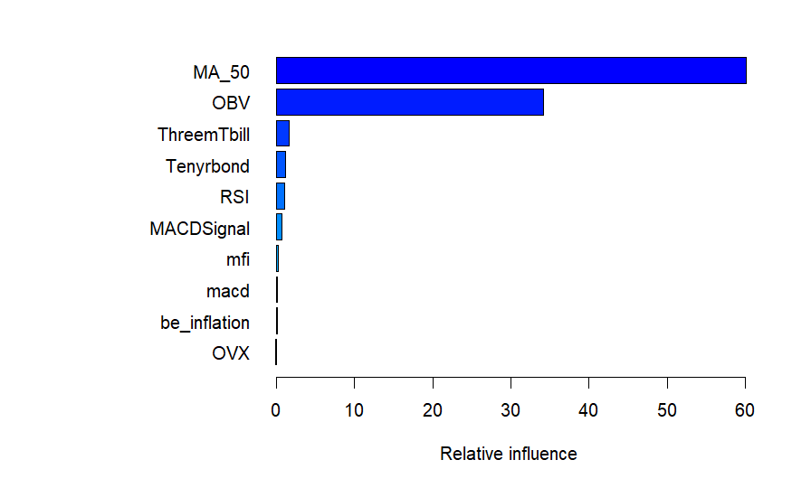

```r
#cBar defines how many variables
#back to orginal window
par(mai=mai.old)
```

Dataset after Top-10 features selected based on importance using Gradient Boosting Models

```r
final_df = new_df1[,c('Date','Price','MA_50','OBV','ThreemTbill','RSI','Tenyrbond','MACDSignal','mfi','macd','be_inflation','OVX')]
write.csv(final_df,"C://Users/manoj/Desktop/BEFD_Project_Images/df.csv")
```

ARIMA Modeling

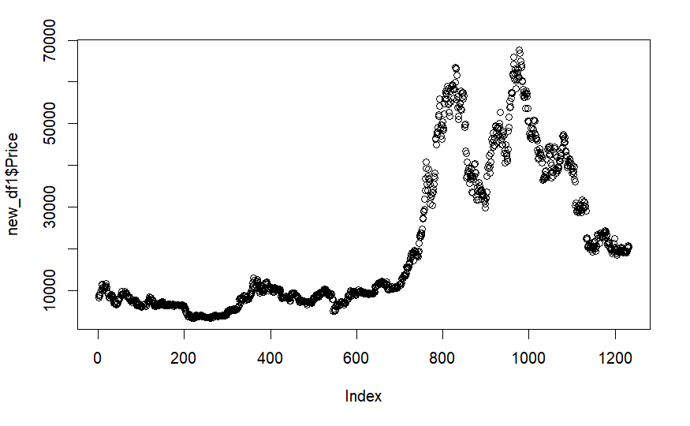

```r
plot(new_df1$Price)
```

```r
library(stats)

# Convert the data to a time series object
ts_data_train <- ts(final_df$Price[2:1222], frequency = 5)
ts_data_test <- ts(final_df$Price[1222:1232], frequency = 5)
ts_data <- ts(final_df$Price[2:1232], frequency = 5)

# Decompose the time series using the stl function
stl_decomposition <- stl(ts_data_train, s.window = "periodic")

# Extract the seasonality, trend, and remainder components
seasonality <- stl_decomposition$time.series[, 1]
trend <- stl_decomposition$time.series[, 2]
remainder <- stl_decomposition$time.series[, 3]
#acf(new_df1$Price, lag.max=34)
```

The Augmented Dickey-Fuller (ADF) test is a statistical test used to determine whether a time series data exhibits stationarity, which is a necessary condition for testing for seasonality. The ADF test returns a p-value and a test statistic, which can be used to assess the likelihood that the data is stationary.

```r
library(tseries)
adf.test(ts_data)
```

```
    Augmented Dickey-Fuller Test

data:  ts_data
Dickey-Fuller = -1.5127, Lag order = 10, p-value = 0.7846
alternative hypothesis: stationary
```

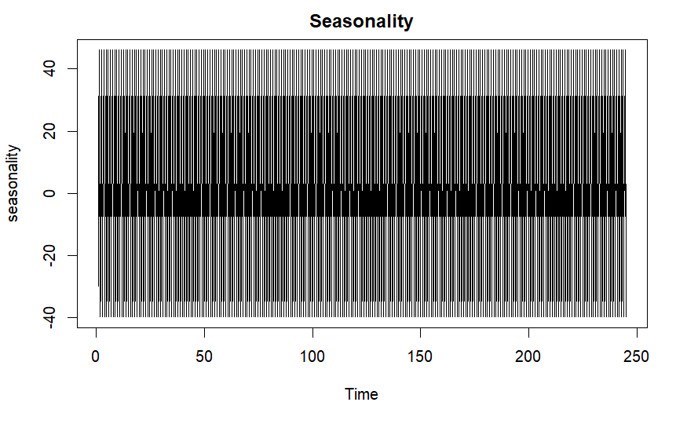

```r
# Plot the seasonality, trend, and remainder components
plot(seasonality, main = "Seasonality")
```

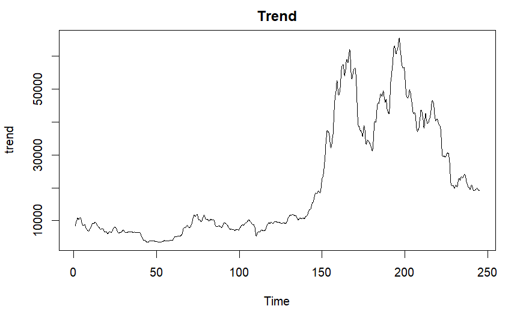

```r
plot(trend, main = "Trend")
```

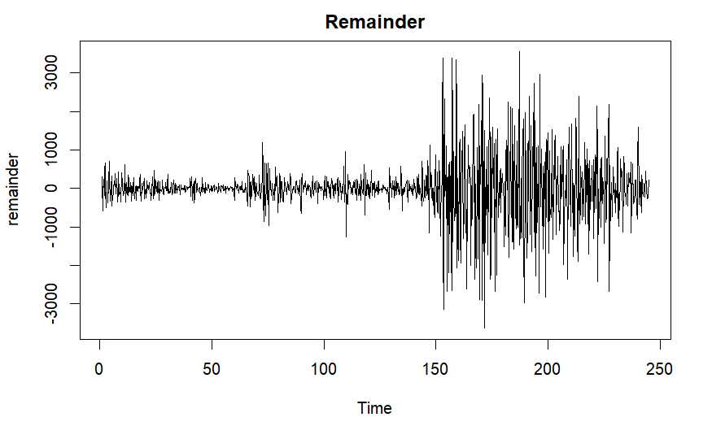

```r
plot(remainder, main = "Remainder")
```